# Lab 1: Using R for linear algebra, data sampling and simulation

In this practical, we are going to see how to use `R` for exploration and visualisation of mathematical and statistical concepts that lie at the heart of data science: vector spaces and sampling. In exercise 1, we look at vector spaces and linear algebra from the point of view of data analysis; in exercise 2 we generate data by sampling from a probability distribution; in exercise 3, we generalise this approach to multivariate probability distributions. Exercises 2 and 3 are not dependent on 1, so you can either work in order or start from 2 and 3 and then attempt 1.

## Exercise 1 (Data vectors and data matrices)

A data set with $n$ observations and $p$ features comes in the form of a $n \times p$ matrix, called the **data matrix**. More precisely, we can write our data as a matrix of the form

$$\mathbf{X} = \begin{pmatrix}
x_{11} & x_{12} & \cdots & x_{1p} \\
x_{21} & x_{22} & \cdots & x_{2p} \\
\vdots & \vdots & \vdots & \vdots\\
x_{n1} & x_{n2} & \cdots & x_{np} \\
\end{pmatrix}$$

where each row is an observation (or measurement) and each column is a feature (or variable). This is a powerful way of encoding data: many algorithms and procedures in data science use linear algebra by considering the $n$ observations as **vectors** belonging to a $p$ dimensional **vector space**.

### **Task 1a**

Let $p=2$ and $n=5$. Consider the data matrix

$$\mathbf{X} = \begin{pmatrix}
1 & 2 \\
1 & 3 \\
0 & -3\\
1 & 1 \\
-2 & 0
\end{pmatrix}.$$

Visualise the 5 observations as vectors in a 2-dimensional real vector space.

**Click for solution**

Many options are possible here. Here is one that uses the package `ggplot2` that you can compare with your choice. You first create a data frame for ggplot and define starting and ending point of your vectors based on this:

```r
library(ggplot2)
```

```r
df <- data.frame(v1 = c(1,1,0,1,-2), v2 = c(2,3,-3,1,0))
segments <- data.frame(x = rep(0,5), y = rep(0,5), df)
```

Then you plot your vectors using the *ggplot()* command:

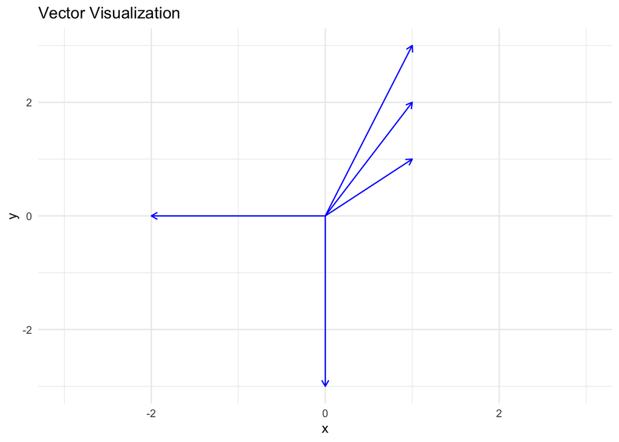

```r
ggplot() +
  geom_segment(data = segments, aes(x = x, y = y, xend = v1, yend = v2),
               arrow = arrow(length = unit(0.2, "cm")), color = "blue") +
  xlim(-3, 3) + ylim(-3, 3) +
  labs(title = "Vector Visualization", x = "x", y = "y") +
  theme_minimal()
```

While it is very useful to think of data points as vectors, a scatterplot provides a simpler and more effective visualisation of our data set

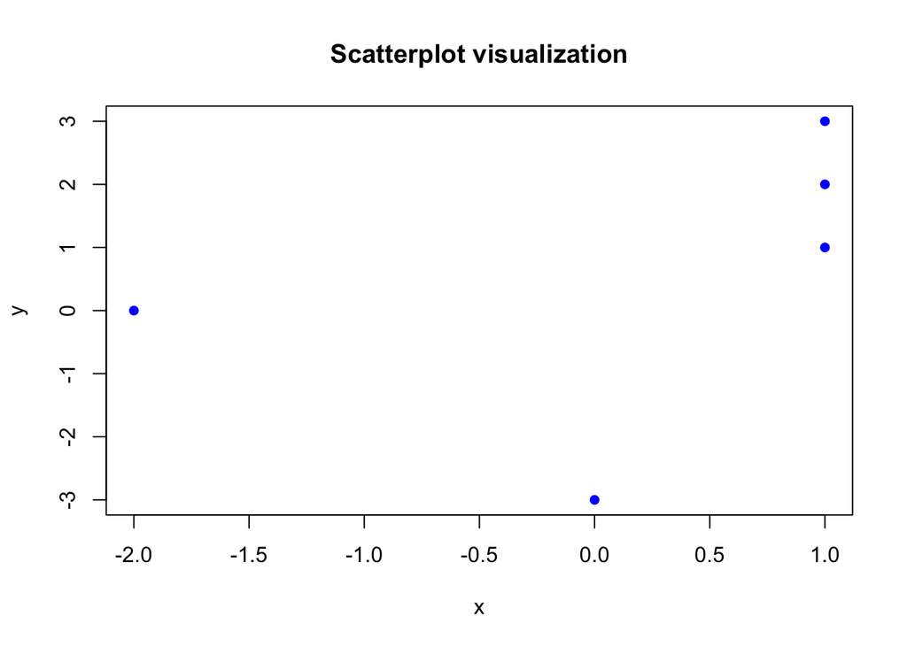

For the next task, you need to check how far is our data set from the red line below

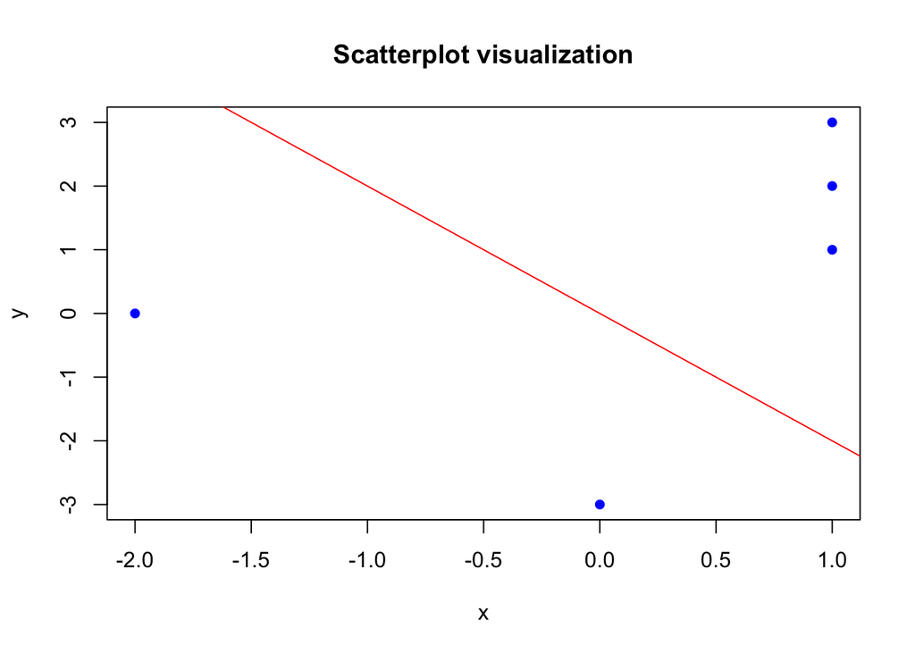

The red line pictured above has equation $y+2x=0$. It can be thought as the vector space of all points of the form $(t,-2t)$ for all possible real values of $t$. This means that it is the line through the origin that moves in the direction of the vector $\mathbf{v} = (1, -2)$.

### **Task 1b**

Compute the distance of the five points in your data set from the red line above. Recall that one of the many formulas for the distance from a point $\mathbf{Q}=(x,y)$ to a line $t\mathbf{v}$ in 2D space is
$$d = \frac{|\mathrm{det}(\mathbf{Q},
\mathbf{v})|}{||\mathbf{v}||}$$
where the numerator is the absolute value of the determinant of the 2x2 matrix with columns $\mathbf{Q}$ and $\mathbf{v}$ and the denominator is the length of the vector $\mathbf{v}$. Using this formula, create a column vector of length 5 containing the distances of the 5 blue points from the red line: you can think of this as a data frame with 5 observations of one variable (the distance from the line).

**Click for solution**

We first define a function to compute the distance using the formula above

```r
distance_to_line <- function(point) {
  v <- c(1, -2)
matrix <- cbind(point, v)
  distance <- abs(det(matrix)) / sqrt(v[1]^2 + v[2]^2)
  return(distance)
}
```

We can then apply the function to the points of our data frame to obtain the vector of distances

```r
distance <- apply(df, 1, distance_to_line)
distance
```

```
## [1] 1.788854 2.236068 1.341641 1.341641 1.788854
```

### **Task 1c (advanced)**

Visualise the distances above with an appropriate 2D plot.

**Click for solution**

Many possible options. Here is a solution using *ggplot()*:

we first define the objects that we need to plot the line

```r
line_data <- data.frame(x = seq(-2, 1.5, length.out = 100))
line_data$y <- -2*(line_data$x)
```

then we compute the perpendicular points on the line

```r
df$proj_x <- (df$v1 - 2 * (2 * df$v1 + 1 * df$v2) / 5)
df$proj_y <- (df$v2 - (2 * df$v1 + 1 * df$v2) / 5)
```

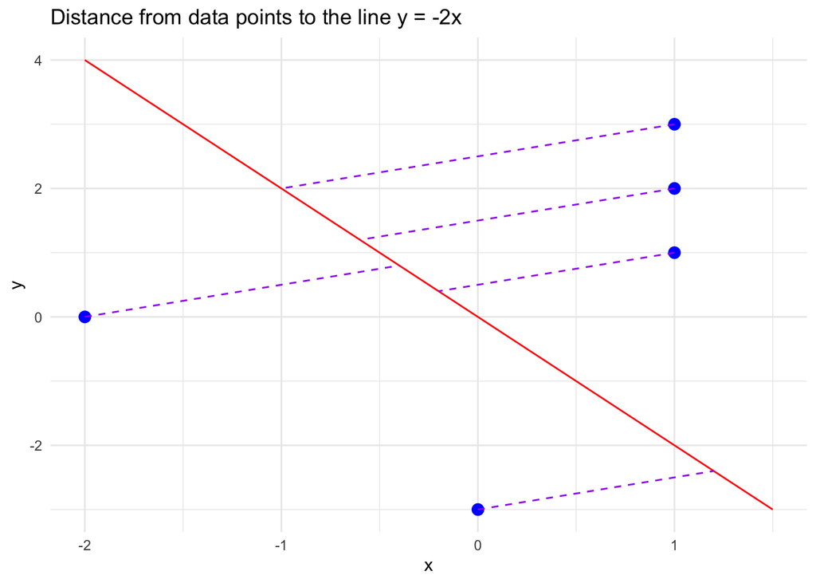

```r
ggplot() +
  geom_line(data = line_data, aes(x = x, y = y), color = "red") +
  geom_point(data = df, aes(x = v1, y = v2), color = "blue", size = 3) +
  geom_segment(data = df, aes(x = v1, y = v2, xend = proj_x, yend = proj_y),
               linetype = "dashed", color = "purple") +
  theme_minimal() +
  ggtitle("Distance from data points to the line y = -2x")
```

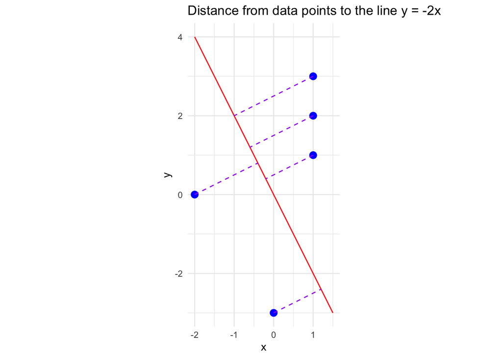

```r
ggplot() +
  geom_line(data = line_data, aes(x = x, y = y), color = "red") +
  geom_point(data = df, aes(x = v1, y = v2), color = "blue", size = 3) +
  geom_segment(data = df, aes(x = v1, y = v2, xend = proj_x, yend = proj_y),
               linetype = "dashed", color = "purple") +
  coord_fixed(ratio = 1) +
  theme_minimal() +
  ggtitle("Distance from data points to the line y = -2x")
```

## Exercise 2 (Simulating data)

**Statistical simulation** is a statistical technique where we artificially generate (“simulate”) data in order to explore sampling distributions, investigate the behaviour of statistical methods, and perform machine learning algorithms. These methods are particularly useful when the corresponding mathematical calculations are difficult or even impossible. Of course, since our results are a product of how we set up the simulation we must take particular care in setting up the problem and interpreting what we find.

We start with sampling from uniform distribution: type

```r
?Uniform
```

to learn the syntax of functions relative to the uniform distribution.

### **Task 2a**

Sample 1000 observations from a uniform distribution on the interval $[0,1]$. Plot the histogram of the sampled data and overlay the theoretical probability density function (PDF).

**Click for solution**

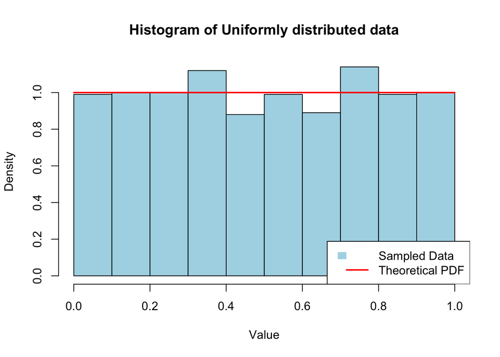

```r
samples <- runif(1000, min = 0, max = 1)
hist(samples, probability = TRUE, main = "Histogram of Uniformly distributed data",
     xlab = "Value", ylab = "Density", col = "lightblue", border = "black")
curve(dunif(x, min = 0, max = 1), col = "red", lwd = 2, add = TRUE)
legend("bottomright", legend = c("Sampled Data", "Theoretical PDF"),
       col = c("lightblue", "red"), lwd = c(NA, 2), fill = c("lightblue", NA), border = NA)
```

Then we can study sampling from a normal distribution. Here we need to specify mean and standard deviation.

### **Task 2b**

Sample 500 observations from a standard normal distribution and 500 observations from a normal distribution with mean 0 and standard deviation 2. Compare the two samples by plotting histograms either side by side or in the same plot.

**Click for solution**

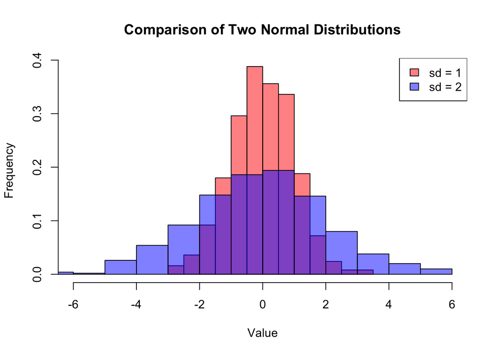

```r
sample1 <- rnorm(500, mean = 0, sd = 1)
sample2 <- rnorm(500, mean = 0, sd = 2)

hist(sample1, col=rgb(1, 0, 0, 0.5), xlim=c(-6, 6), main="Comparison of Two Normal Distributions", xlab="Value", ylab="Frequency", freq=FALSE)
hist(sample2, col=rgb(0, 0, 1, 0.5), add=TRUE, freq=FALSE)

legend("topright", legend=c("sd = 1", "sd = 2"), fill=c(rgb(1, 0, 0, 0.5), rgb(0, 0, 1, 0.5)))
```

In ISDS, you have used normal Q-Q plots to assess if a certain quantity is approximately normally distributed. We now test how good are these on simulated data: if we use the *qqnorm()* function, we can see that the quantiles of the simulated data are compatible with those of a theoretical normal distribution (as expected), but they are not perfect even with sample sizes of 500! This is more apparent around the tails.

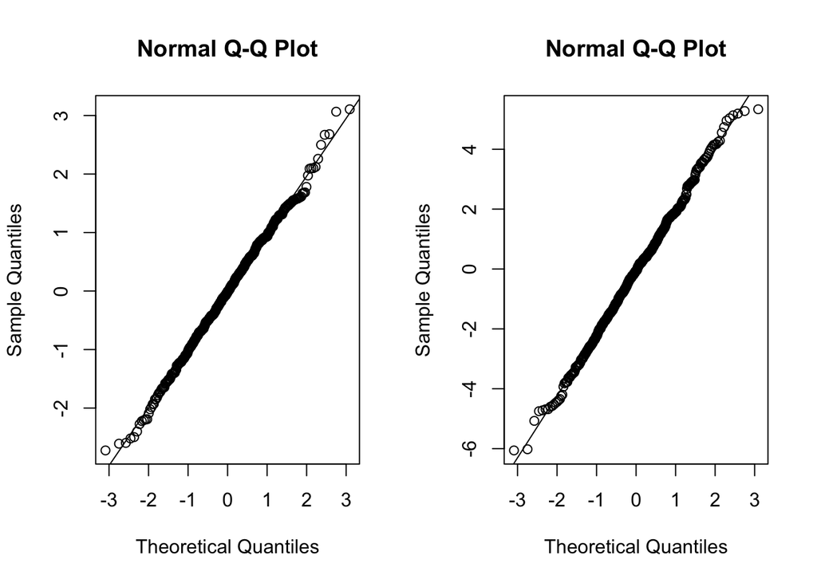

```r
par(mfrow=c(1,2))

qqnorm(sample1)
qqline(sample1)
qqnorm(sample2)
qqline(sample2)
```

### **Task 2c**

Is the sum of two normally distributed random variables again normal? And what about the product? To experimentally check this, create normal Q-Q plots of the sum of the two samples above, and of the product. What are your conclusions?

**Click for solution**

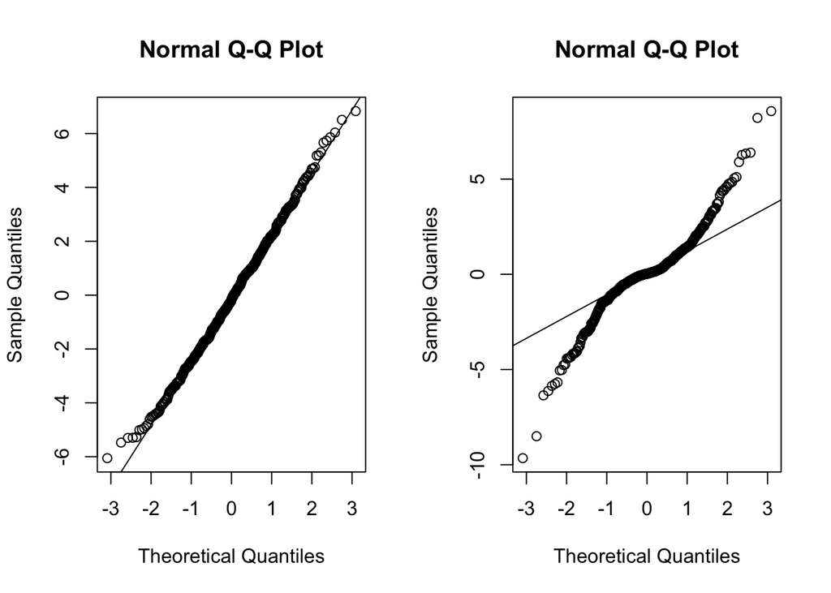

```r
par(mfrow=c(1,2))

qqnorm(sample1+sample2)
qqline(sample1+sample2)
qqnorm(sample1*sample2)
qqline(sample1*sample2)
```

## Exercise 3 (Multivariate normal sampling)

We will look at sampling from multivariate probability distributions. For this exercise, we will make a popular choice and use the **multivariate standard normal distribution** (aka multivariate Gaussian distribution) $N(\boldsymbol{\mu} = \boldsymbol{0}, \boldsymbol{\Sigma}=\boldsymbol{I})$. Now the parameters are not just numbers, as in the case of univariate normal distributions, but vectors (in the case of the mean) and matrices (in the case of covariance).

**Read more**

Multivariate normal distributions are the most studied and most useful of multivariate probability distributions. A vector of random variables $\mathbf{Y}:= \begin{pmatrix} Y_1\\ \vdots\\ Y_p \end{pmatrix}$ is said to be normally distributed if every linear combination $a_1 Y_1 + \dots + a_p Y_p$ is normally distributed.

The multivariate Gaussian distribution $N(\boldsymbol{\mu} = \boldsymbol{0}, \boldsymbol{\Sigma}=\boldsymbol{I})$ is the special case of a multivariate normal that has mean $\boldsymbol{0}$ (the vector whose elements are all zero) and covariance matrix $\boldsymbol{I}$ (the identity matrix of dimension $p \times p$).

With this theoretical framework in mind, let us simulate some data:

- Load the following package into your workspace.

  ```r
  library(MASS)
  ```

- run ?mvrnorm in console and see Help tab to check how to use this function to generate data from a multivariate normal distribution.

  ```r
  ?mvrnorm
  ```

You are now ready to perform the following tasks:

### **Task 3a**

Generate the multivariate Gaussian data $\mathbf{X} \sim N(\boldsymbol{0}, \mathbf{I}_p)$ with $n=50$ and $p=10$, and check its dimension.

**Solution to Task 3a**

**Click for solution**

```r
n <- 50
p <- 10
mu <- rep(0, p)
Sigma <- diag(p)

set.seed(2024)
dat <- mvrnorm(n = n, mu = mu, Sigma = Sigma)
dim(dat)
```

```
## [1] 50 10
```

### **Task 3b**

Obtain the estimated mean vector $\hat{\mu}$ and check it is close to the true parameters, $\mu$.

**Solution to Task 3b**

**Click for solution**

```r
muhat <- colMeans(dat)
cbind(mu, muhat)
```

```
##       mu       muhat
##  [1,]  0  0.02471851
##  [2,]  0  0.12684999
##  [3,]  0  0.05368035
##  [4,]  0  0.05309381
##  [5,]  0  0.05201272
##  [6,]  0  0.10833111
##  [7,]  0  0.23795856
##  [8,]  0  0.02617100
##  [9,]  0 -0.09426008
## [10,]  0 -0.07560478
```

### **Task 3c**

Compute the estimated covariance matrix $\hat{\Sigma}$ and check that it is close to the true covariance matrix $\Sigma$. Comparing large matrices by eyes is a bit tricky. Can you think of a better way to visually do this comparison?

**Solution to Task 3c**

**Click for solution**

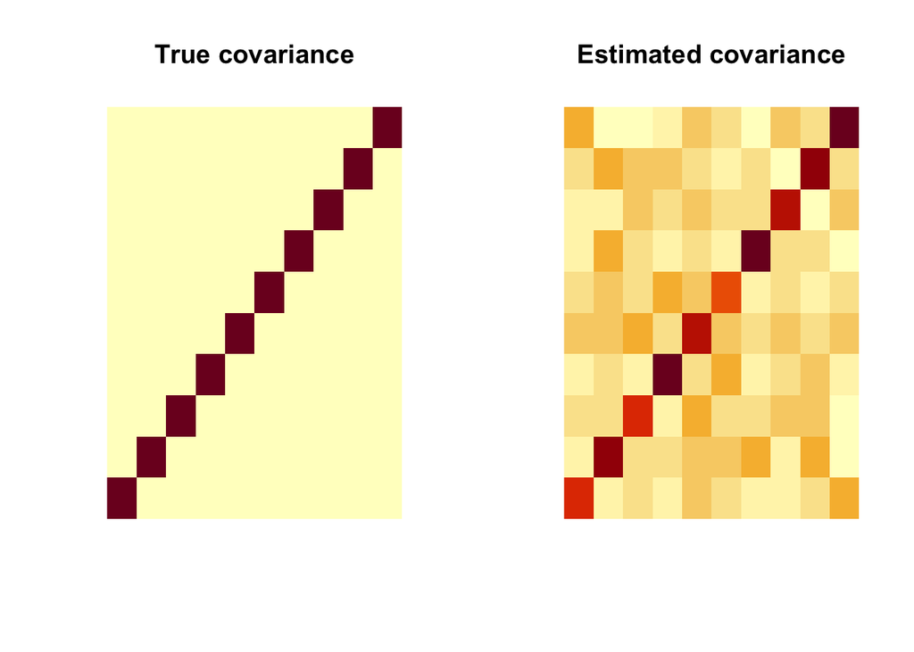

```r
Sigmahat <- cov(dat)
par(mfrow=c(1, 2))
image(Sigma, main = "True covariance", axes=FALSE)
image(Sigmahat, main = "Estimated covariance", axes=FALSE)
```

That’s not quite what we expected. Why? Because image() in R rotates the matrix, so we need to change the input.

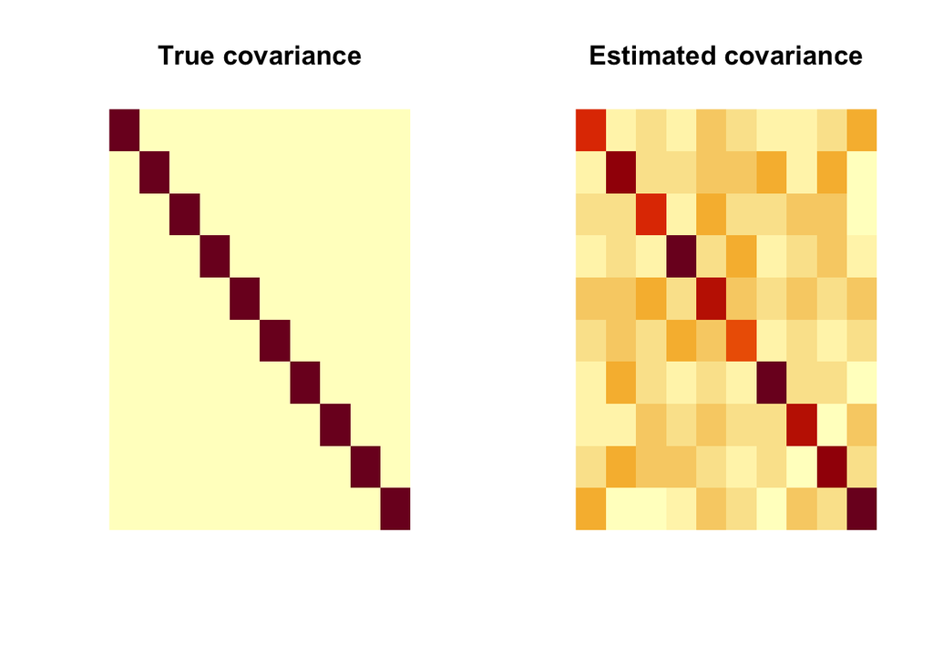

```r
par(mfrow=c(1, 2))
image(Sigma[,nrow(Sigma):1], main = "True covariance", axes=FALSE)
image(Sigmahat[,nrow(Sigmahat):1], main = "Estimated covariance", axes=FALSE)
```